# STAT/MATH 495: Problem Set 03

Jeff Lancaster

2017-09-26

# Question

For both `data1` and `data2` tibbles (a tibble is a data frame with some [metadata](https://blog.rstudio.com/2016/03/24/tibble-1-0-0#tibbles-vs-data-frames) attached):

- Find the splines model with the best out-of-sample predictive ability.
- Create a visualization arguing why you chose this particular model.
- Create a visualization of this model plotted over the given $(x_i, y_i)$ points for $i=1,\ldots,n=3000$.
- Give your estimate $\widehat{\sigma}$ of $\sigma$ where the noise component $\epsilon_i$ is distributed with mean 0 and standard deviation $\sigma$.

# The Plan for simple splines

1. Create splines models and calculate the MSE of each of them, storing them in a data frame with the MSE value and df.
2. Graph df~MSE using the data created above
3. Find the value of df that minimizes MSE to justify our choice
4. Plot the model

# The plan for using cross validation to find the best splines model

1. Randomly sample (without replacement) 1/10 of the data. Do it 9 times so you have 10 equal data sets
2. Repeat the simple plan using each segment in turn as the basis for the model, then test that model on the other 9 sets. Store the MSEs of each (should be 9*9=81) and average them, returning the total as the MSE for that particular model.
3. You should have 9 total MSEs at this point (one for each 1/10 of the dataset). Choose the one that works best.

# Data 1

```r
#Function to calculate MSE for a test set, a train set, and a specified value for df
MSE_calc <- function(x,train,test){
  splines_model <- smooth.spline(train$x, train$y, df=x)
  output <- predict(splines_model, test$y) %>%
    tibble::as.tibble()
  mean((test[,2]-output$y)^2) #this is the MSE
}

#now attempting to create cross-validate sets
n <- 600
nr <- nrow(data1)

train1<-as.data.frame(split(data1, rep(1:ceiling(nr/n), each=n, length.out=nr))[1])
colnames(train1) <- c("ID", "x","y")
train2<-as.data.frame(split(data1, rep(1:ceiling(nr/n), each=n, length.out=nr))[2])
colnames(train2) <- c("ID", "x","y")
train3<-as.data.frame(split(data1, rep(1:ceiling(nr/n), each=n, length.out=nr))[3])
colnames(train3) <- c("ID", "x","y")
train4<-as.data.frame(split(data1, rep(1:ceiling(nr/n), each=n, length.out=nr))[4])
colnames(train4) <- c("ID", "x","y")
train5<-as.data.frame(split(data1, rep(1:ceiling(nr/n), each=n, length.out=nr))[5])
colnames(train5) <- c("ID", "x","y")

test1 <- anti_join(data1,train1,by="ID")
test2 <- anti_join(data1,train2,by="ID")
test3 <- anti_join(data1,train3,by="ID")
test4 <- anti_join(data1,train4,by="ID")
test5 <- anti_join(data1,train5,by="ID")
```

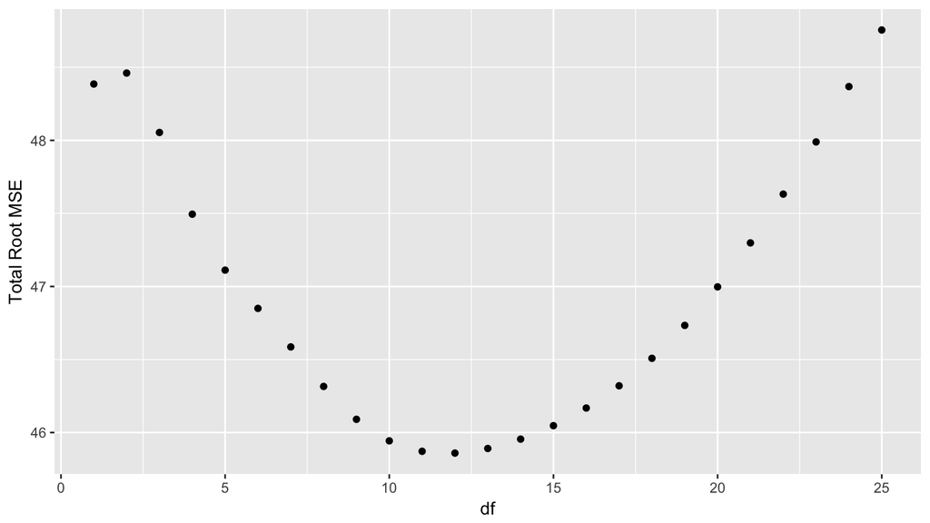

```r
set.seed(5)
df_x2 <- c(1:25)
df_y2 <- c(1:25)
for (i in 2:26){
  df_y2[i-1] <- (sqrt(MSE_calc(i,train1,test1)) + sqrt(MSE_calc(i,train2,test2)) +
                sqrt(MSE_calc(i,train3,test3)) + sqrt(MSE_calc(i,train4,test4)) +
                sqrt(MSE_calc(i,train5,test5)))/5
}
MSE_plot2 <- data.frame(df_x2,df_y2)
ggplot(MSE_plot2,aes(x=df_x2,y=df_y2))+geom_point()+xlab("df")+ylab("Total Root MSE")
```

As we can see, when we use cross validation on the “data1” dataset using 5 partitions, we find that the value for degrees of freedom that minimizes Root MSE is 12.

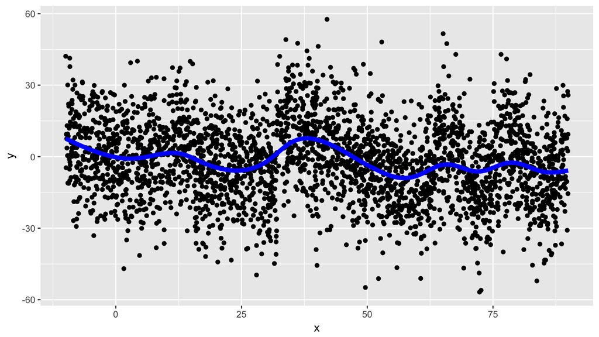

```r
splines_model <- smooth.spline(x=data1$x, y=data1$y, df = 12)
splines_model_tidy <- splines_model %>%
  broom::augment()
plot <- ggplot(splines_model_tidy, aes(x=x)) +
  geom_point(aes(y=y)) +
  geom_line(aes(y=.fitted),size=2, col="blue")
plot
```

Above is the goodness of fit curve for my spline applied to the whole dataset

My estimation of $\sigma$ would be $\widehat{\sigma}=45.8592884$ because it is the value of root MSE that corresponds to the optimal degrees of freedom, 12.

# Data 2

```r
n <- 600
nr <- nrow(data2)

train1<-as.data.frame(split(data2, rep(1:ceiling(nr/n), each=n, length.out=nr))[1])
colnames(train1) <- c("ID", "x","y")
train2<-as.data.frame(split(data2, rep(1:ceiling(nr/n), each=n, length.out=nr))[2])
colnames(train2) <- c("ID", "x","y")
train3<-as.data.frame(split(data2, rep(1:ceiling(nr/n), each=n, length.out=nr))[3])
colnames(train3) <- c("ID", "x","y")
train4<-as.data.frame(split(data2, rep(1:ceiling(nr/n), each=n, length.out=nr))[4])
colnames(train4) <- c("ID", "x","y")
train5<-as.data.frame(split(data2, rep(1:ceiling(nr/n), each=n, length.out=nr))[5])
colnames(train5) <- c("ID", "x","y")

test1 <- anti_join(data2,train1,by="ID")
test2 <- anti_join(data2,train2,by="ID")
test3 <- anti_join(data2,train3,by="ID")
test4 <- anti_join(data2,train4,by="ID")
test5 <- anti_join(data2,train5,by="ID")
```

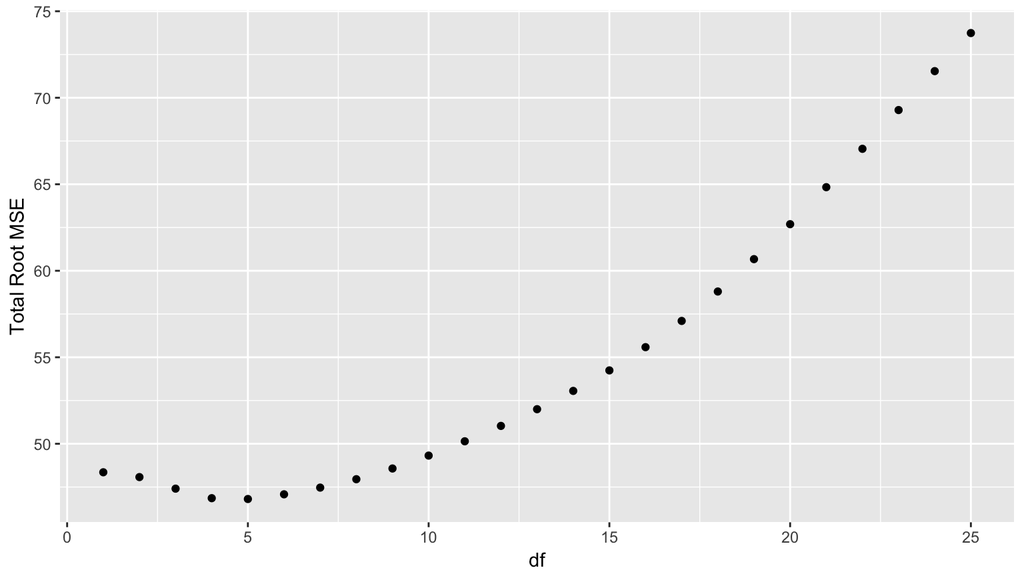

```r
set.seed(5)
df_x2 <- c(1:25)
df_y2 <- c(1:25)
for (i in 2:26){
  df_y2[i-1] <- (sqrt(MSE_calc(i,train1,test1)) + sqrt(MSE_calc(i,train2,test2)) +
                sqrt(MSE_calc(i,train3,test3)) + sqrt(MSE_calc(i,train4,test4)) +
                sqrt(MSE_calc(i,train5,test5)))/5
}
MSE_plot2 <- data.frame(df_x2,df_y2)
ggplot(MSE_plot2,aes(x=df_x2,y=df_y2))+geom_point()+xlab("df")+ylab("Total Root MSE")
```

As we can see, when we use cross validation on the “data2” dataset using 5 partitions, we find that the value for degrees of freedom that minimizes Root MSE is 5.

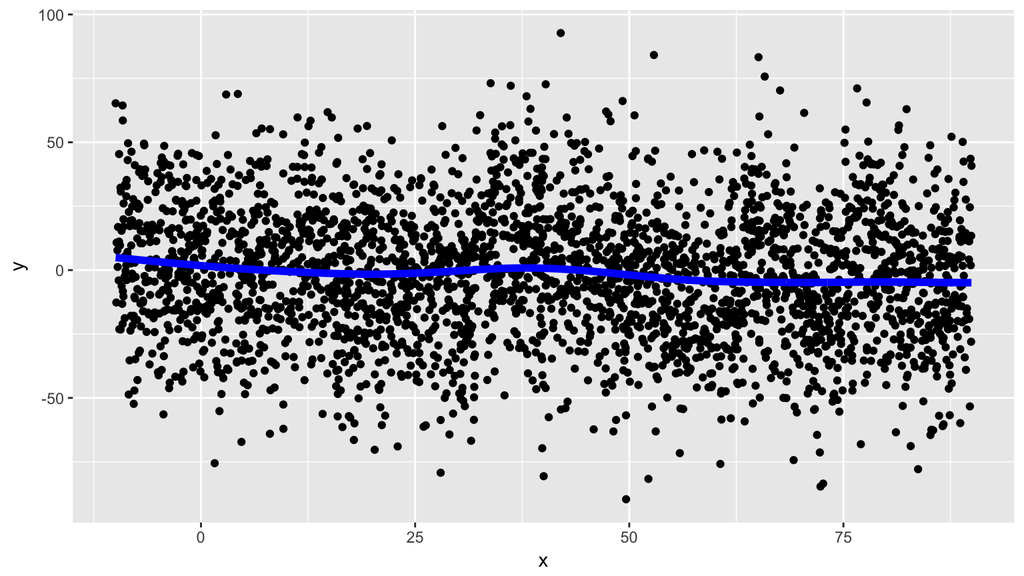

```r
splines_model <- smooth.spline(x=data2$x, y=data2$y, df = 5)
splines_model_tidy <- splines_model %>%
  broom::augment()
plot <- ggplot(splines_model_tidy, aes(x=x)) +
  geom_point(aes(y=y)) +
  geom_line(aes(y=.fitted),size=2, col="blue")
plot
```

Above is the goodness of fit curve for my spline applied to the whole dataset